# Regression Analysis - STAT 482 - HW #4

Alex Towell (atowell@siue.edu)

# Problem 1

Refer to the data from Exercise 1.20

Data has been collected on $45$ calls for routine maintenance. The goal is to explore the relationship between the number of copiers serviced $(x)$ and the time in minutes spent to complete the service $(y)$.

In a confidence band, the error of interest is the maximum error across the input space $x_1,\ldots,x_n$. That is, we are interested in
$$\max_x
\frac{\left(\hat{y}(x)-\mu(x)\right)^2}{\hat{\operatorname{V}}(\hat{y}(x))}
\sim 2 F(2,n-2).$$

Thus, a confidence band estimate for $\mu(x) = \beta_0 + \beta_1 x$ for all $x$ is defined by the functions
$$L(x) = \hat{y}(x) - c \sqrt{\hat{\operatorname{V}}(\hat{y}(x))}$$
and
$$U(x) = \hat{y}(x) + c \sqrt{\hat{\operatorname{V}}(\hat{y}(x))}$$
where
$$c = \sqrt{2 F(1-\alpha,2,n-2)}.$$

```r
call.data = read.table('CH01PR20.txt')
colnames(call.data) = c("time","copiers")
call.mod = lm(time ~ copiers, data=call.data)

b0 = call.mod$coefficients[1]; names(b0) = NULL
b1 = call.mod$coefficients[2]; names(b1) = NULL

e = call.mod$residuals
n = length(e)
sse = sum(e^2)
dfe = n-2
mse = sse / dfe

x.all = 1:10
x.sample = call.data$copiers
x.bar = mean(x.sample)
x.star = x.sample - x.bar
ssx = sum(x.star^2)

x.h = 3
y.h = b0 + b1*x.h
y.h.l = y.h - sqrt(2*qf(.95,2,dfe))*sqrt(mse*(1/n+(x.h-x.bar)^2/ssx))
y.h.u = y.h + sqrt(2*qf(.95,2,dfe))*sqrt(mse*(1/n+(x.h-x.bar)^2/ssx))

c(y.h.l,y.h.u)
```

```
## [1] 40.27853 48.77265
```

We see that the confidence band at $x_h = 3$ is given by
$$[40.2785284, 48.7726465].$$

As we increase the scope of the estimation/prediction, we increase the probability of data incompatible with a model. Thus, we need to increase the range of compatibility.

I was amused by the quote “The really unusual day would be one where nothing unusual happens.”

A $95\%$ confidence band is given by an upper and lower limit such that, with repeated sampling, $95\%$ of the time, none of the sample points will be outside of these limits. This contrasts with a confidence interval, where we are only interested in a single point. Thus, a standard CI is too narrow and must be appropriately widened.

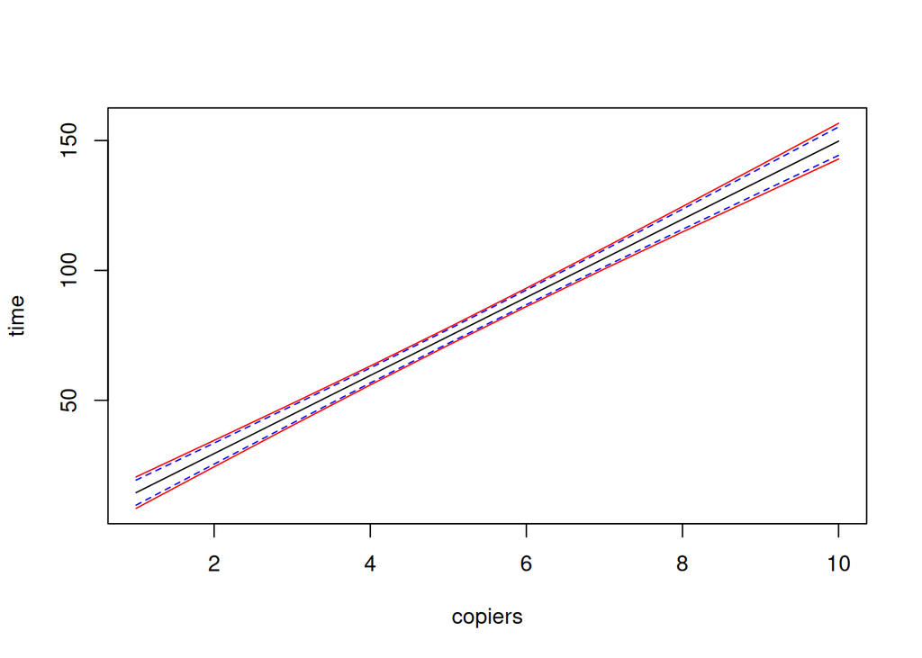

```r
y.hat = b0 + b1*x.all
y.lower = y.hat - sqrt(2*qf(.95,2,dfe))*sqrt(mse*(1/n+(x.all-x.bar)^2/ssx))
y.upper = y.hat + sqrt(2*qf(.95,2,dfe))*sqrt(mse*(1/n+(x.all-x.bar)^2/ssx))
y.all = matrix(c(y.hat,y.lower,y.upper),ncol=3)

colnames(y.all) = c("mean.y","lower.limit","upper.limit")
#cbind(x.all,y.all)

matplot(x.all,y.all,type="l",lty=1,col=c("black","red","red"),
        xlab = "copiers",ylab = "time")

call.ci = predict(call.mod,data.frame(copiers=x.all),interval = "confidence")
call.ci = cbind(x.all,call.ci)
#call.ci

y.lwr = call.ci[,3]
y.upp = call.ci[,4]
points(x.all,y.lwr,type="l",lty=2,col="blue")
points(x.all,y.upp,type="l",lty=2,col="blue")
```

# Problem 2

Refer to the data from Exercise 1.27

A person’s muscle mass is expected to decrease with age. To explore this relationship in women, a nutritionist randomly selected $15$ women for each $10$ year age group, beginning with $40$ and ending with age $79$. The input variable $x$ is age (in years), and the response variable $y$ is muscle mass (in muscle mass units).

Recall that $\operatorname{E}(\operatorname{MS_E}) = \sigma^2$. The expected value of the $\operatorname{MS_R}$ is
$$\operatorname{E}(\operatorname{MS_R}) = \sigma^2 +
\operatorname{SS_X}\beta_1^2.$$

If $\beta_1 \approx 0$, then $\operatorname{E}(\operatorname{MS_R}) \approx \operatorname{E}(\operatorname{MS_E})$.

The test statistic is given by
$$F^* = \frac{\operatorname{MS_R}}{\operatorname{MS_E}}$$
where a small $F^*$ indicates data compatible with the null model and a large $F^*$ indicates data not compatible with the null model.

Of $\beta_1 = 0$ (no effect model), then $F^* \sim F(1,n-2)$. The $p$-value is given by
$$\Pr\left[F(1,n-2) > F^*\right].$$

We compute these results with:

```r
mass.data = read.table('CH01PR27.txt')
colnames(mass.data) = c("mass","age")
mass.mod = lm(mass ~ age, data=mass.data)
anova(mass.mod)
```

```
## Analysis of Variance Table
##
## Response: mass
##           Df  Sum Sq Mean Sq F value    Pr(>F)
## age        1 11627.5 11627.5  174.06 < 2.2e-16 ***
## Residuals 58  3874.4    66.8
## ---
## Signif. codes:  0 '***' 0.001 '**' 0.01 '*' 0.05 '.' 0.1 ' ' 1
```

From the ANOVA table, we see that $\operatorname{MS_R}= 11627.486$, $\operatorname{MS_E}= 66.8$, and $F^* = \operatorname{MS_R}/ \operatorname{MS_E}= 174.06$. This value of the test statistic has a $p$-value given by $.000$.

Interpretation: Since the data is not compatible with the no effect model, we accept the model which includes age as a predictor.

The coefficient of determination is the proportion of variation in the response $Y$ that is explained by input $x$,
$$r^2 = \frac{\operatorname{SS_R}}{\operatorname{SSTO}}.$$

We compute the coefficient of determination with:

```r
summary(mass.mod)$r.squared
```

```
## [1] 0.7500668
```

Since the sample correlation is given by $r = \sqrt{r^2} = 0.87$, these two variables appear to be significantly correlated.